# Feldversuche planen in R

Author

Anja Eggert

Published

November 10, 2024

# R Bibliotheken

```r
library(tidyverse)   # Tidy Universum
library(agricolae)   # Versuchsanlagen erstellen
library(desplot)     # Feldpläne erstellen
```

Mit dem R Paket `agricolae` können sehr verschiedene Versuchsanlagen erstellt werden. Auf der Webseite Experimental Designs with agricolae gibt es ein Tutorium, allerdings auf englisch. Hier wird anschließend das R Paket `desplot`genutzt, um den Versuch in einem Feldplan darzustellen.

# Drei Versuchsanlagen

In dieser Übung sollen drei verschiedene Versuchsanlagen erstellt werden:

- Vollständig Randomisierte Anlage / Complete Randomized Design (**CRD**)
- Randomisierte Vollständige Blockanlage / Randomized Complete Block Design (**RCBD**)
- Spaltanlage / Split-Plot Design (**SPD**)

# Ein Beispiel

In einer Region, die bereits von der Zuckerrübenkrankheit Syndrome Basses Richesses (SBR) betroffen ist, soll ein Feldversuch durchgeführt werden. Es soll untersucht werden, ob es Sorten gibt, die weniger von der Krankheit befallen werden. Außerdem soll untersucht werden, ob die Bodenbearbeitung einen Einfluss auf den Befall hat.

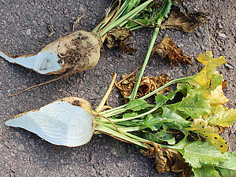

https://www.lfl.bayern.de/ips/blattfruechte/339679

## 2-faktorieller Feldversuch

Es ist also ein 2-faktorieller Feldversuch. Es sollen drei Sorten (S1, S2, S3) und zwei verschiedene Bodenbearbeitungen (B1, B2) getestet werden. Die beiden Faktoren werden hier definiert:

```r
# 3 Sorten
Sorte   <- paste0("S", 1:3)  # S1 - S3
n_Sorte <- n_distinct(Sorte) # 3

# 2 Bodenbearbeitungen
Boden   <- paste0("B", 1:2)  # B1 - B2
n_Boden <- n_distinct(Boden) # 2
```

Die beiden Faktoren sollen kreuzklassifiziert untersucht werden, jede Sorte soll also mit jeder Bodenbearbeitung getestet werden. Um dieses Versuchsschema zu definieren, kann man die Funktion `expand,grid()` nutzen:

```r
# Kreuzklassifikation: 3 Sorten x 2 Boden
Behandlung <- expand.grid(Sorte = Sorte,
                          Boden = Boden) %>%
  mutate(Behandlung = paste0(Sorte,"x", Boden)) %>%
  pull(Behandlung) # S1.B1 - S3.B2

n_Behandlung <- n_distinct(Behandlung) # 3*2 = 6
```

Es wird festgelegt, dass der Versuch pro Behandlung 4 Wiederholungen enthalten soll:

```r
# Anzahl der Wiederholungen
n_Wiederholungen <- 4
```

# CRD: 2 Faktoren

Die erste Versuchsanlage ist die Vollständig Randomisierte Versuchsanlage (**CRD**). Die Behandlungen werden den Versuchseinheiten völlig uneingeschränkt und zufällig zugeordnet. Dieses Design ist sehr einfach in der Anlage und auch das statistische Modell für die Auswertung ist sehr einfach. Wenn die Bedinungen auf dem Feld jedoch nicht homogen sind, ist die statistische Teststärke reduziert.

## Versuchsdesign

Mit der Funktion `design.crd()` aus dem R Paket `agricolae`, kann die Versuchsanlage vollständig randomisiert erstellt werden. Für die Reproduzierbarkeit ist die Wahl des `seed =` notwendig, das den Zufallsgenerator in R definiert.

```r
Design_CRD <- design.crd(trt   = Behandlung,
                         r     = n_Wiederholungen,
                         seed  = 1989,
                         kinds = "Super-Duper")
```

## Feldpläne (Tabelle)

Das Ergebnis `Design_CRD` ist eine sogenannte Liste und enthält in `Design_CRD$book` den Feldplan. Für die grafische Darstellung mit dem R Paket `desplot` muss die Tabelle noch angepasst werden:

```r
Feldplan_CRD <- Design_CRD %>%
  pluck("book") %>%
  as_tibble() %>%
  set_names(c("Parzelle", "Wiederholung", "Behandlung"))

# Reihe und Spalte hinzufügen
Feldplan_CRD <- Feldplan_CRD %>%
  bind_cols(expand.grid(Reihe  = 1:(n_Sorte*n_Boden/2),
                        Spalte = 1:(n_Wiederholungen*2)))
```

## Feldpläne (Abbildung)

Mit der Funktion `ggdesplot()` aus dem R Paket `desplot` kann nun der Feldplan grafisch dargestellt werden:

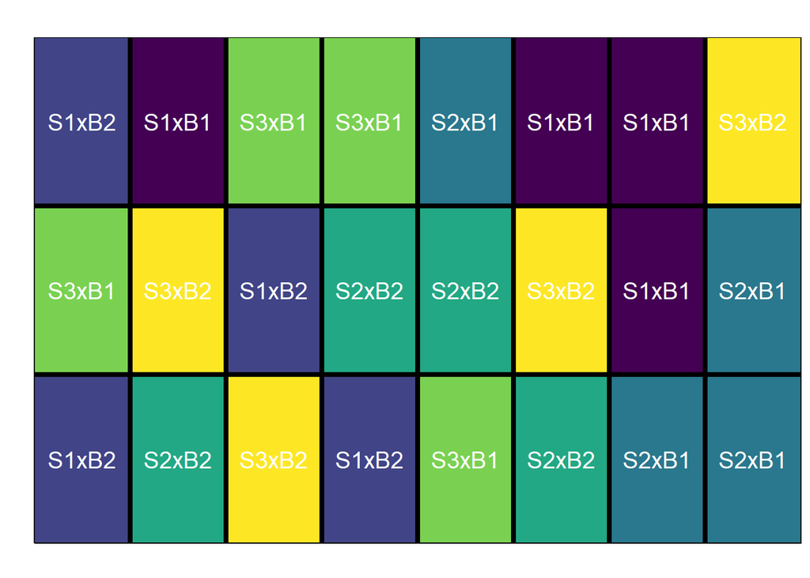

```r
ggdesplot(Behandlung ~ Spalte + Reihe,
          data      = Feldplan_CRD,
          out1      = Parzelle,
          out1.gpar = list(col="grey60", lwd=1),
          flip      = FALSE,
          text      = Behandlung,
          col.text  = "white",
          cex       = 1.3,
          shorten   = "no",
          show.key  = FALSE,
          main      = "") +
  scale_fill_viridis_d()
```

# RCBD: 2 Faktoren

Die zweite Versuchsanlage ist die Randomisierte Vollständige Blockanlage (**RCBD**). Diese Anlage ist sinnvoll, wenn auf dem Versuchsfeld keine homogenen Bedingungen vorliegen. Das Feld wird dann in Blöcke unterteilt, wobei die Bedingungen innerhalb der Blöcke möglichst homogen sind. Die Behandlungen werden innerhalb der Blöcke vollständig und zufällig zugeordnet. Das Design hat den Vorteil, dass Umweltgradienten zwischen Blöcken nicht in den Restfehler einfließen.

## Versuchsdesign

Mit der Funktion `design.ab()` aus dem R Paket `agricolae`, kann die RCBD Versuchsanlage erstellt werden. Für die Reproduzierbarkeit ist die Wahl des `seed =` notwendig, das den Zufallsgenerator in R definiert.

```r
Design_RCBD <- design.ab(trt    = c(n_Sorte, n_Boden),
                         r      = n_Wiederholungen,
                         design = "rcbd",
                         seed   = 1989,
                         kinds  = "Super-Duper")
```

## Feldpläne (Tabelle)

Das Ergebnis `Design_RCBD` ist eine sogenannte Liste und enthält in `Design_RCBD$book` den Feldplan. Für die grafische Darstellung mit dem R Paket `desplot` muss die Tabelle noch angepasst werden:

```r
Feldplan_RCBD <- Design_RCBD %>%
  pluck("book") %>%
  as_tibble() %>%
  set_names(c("Parzelle", "Block", "Sorte", "Boden"))

# Reihe und Spalte hinzufügen
# Block ist Wiederholung
Feldplan_RCBD <- Feldplan_RCBD %>%
  bind_cols(expand.grid(Reihe  = 1:(n_Sorte*n_Boden/2),
                        Spalte = 1:(n_Wiederholungen*2))) %>%
  mutate(Sorte = paste0("S", Sorte),
         Boden = paste0("B", Boden),
         Behandlung = paste0(Sorte,"x", Boden))
```

## Feldpläne (Abbildung)

Mit der Funktion `ggdesplot()` aus dem R Paket `desplot` kann nun der Feldplan grafisch dargestellt werden:

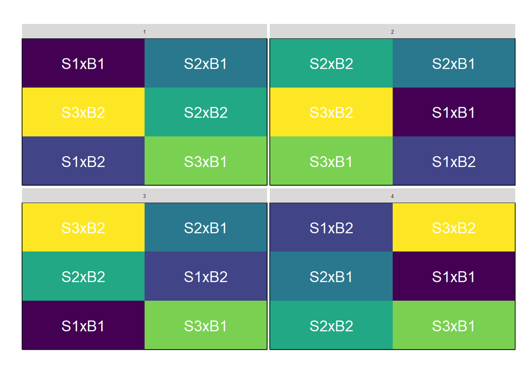

```r
ggdesplot(Behandlung ~ Spalte + Reihe | Block,
          data      = Feldplan_RCBD,
          out1      = Block,
          out1.gpar = list(col="grey60", lwd=1),
          flip      = FALSE,
          text      = Behandlung,
          col.text  = "white",
          cex       = 1.3,
          shorten   = "no",
          show.key  = FALSE,
          main      = "") +
  scale_fill_viridis_d()
```

# SPD: 2 Faktoren

Die dritte Versuchsanlage ist die Spaltanlage (**SPD**). Diese Anlage ist sinnvoll, wenn auf dem Versuchsfeld keine homogenen Bedingungen vorliegen und zusätzlich meist Rahmenbedingungen aus der Praxis vorliegen. Das Feld wird wie bei der RCBD-Anlage in Blöcke unterteilt, wobei die Bedingungen innerhalb der Blöcke möglichst homogen sind. Die Behandlungen werden innerhalb der Blöcke allerdings NICHT vollständig und zufällig zugeordnet. Bei der Spaltanlage gibt es zwei Randomisierungsschritte: Anordnung der Spalten innerhalb der Blöcke und der Parzellen innerhalb der Streifen.

## Versuchsdesign

Mit der Funktion `design.split()` aus dem R Paket `agricolae`, kann die Spaltanlage erstellt werden. Für die Reproduzierbarkeit ist die Wahl des `seed =` notwendig, das den Zufallsgenerator in R definiert.

```r
Design_SPD <- design.split(trt1    = Boden,
                           trt2    = Sorte,
                           r      = n_Wiederholungen,
                           seed   = 1989,
                           kinds  = "Super-Duper")
```

## Feldpläne (Tabelle)

Das Ergebnis `Design_SPD` ist eine sogenannte Liste und enthält in `Design_SPD$book` den Feldplan. Für die grafische Darstellung mit dem R Paket `desplot` muss die Tabelle noch angepasst werden:

```r
Feldplan_SPD <- Design_SPD %>%
  pluck("book") %>%
  as_tibble() %>%
  set_names(c("Streifen", "Parzelle", "Block", "Boden", "Sorte"))

# Reihe und Spalte hinzufügen
# Block ist Wiederholung
# Parzelle ist Subplot
# Streifen ist Main plot
Feldplan_SPD <- Feldplan_SPD %>%
  bind_cols(expand.grid(Reihe  = 1:(n_Sorte*n_Boden/2),
                        Spalte = 1:(n_Wiederholungen*2))) %>%
  mutate(Behandlung = paste0(Sorte,"x", Boden))
```

## Feldpläne (Abbildung)

Mit der Funktion `ggdesplot()` aus dem R Paket `desplot` kann nun der Feldplan grafisch dargestellt werden:

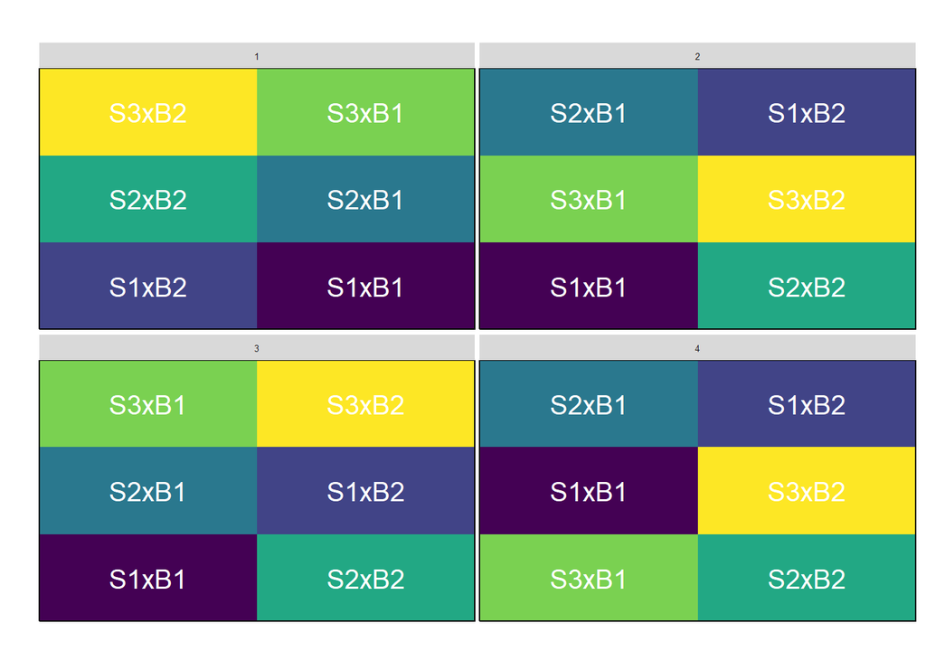

```r
ggdesplot(Behandlung ~ Spalte + Reihe | Block,
          data      = Feldplan_SPD,
          out1      = Block,
          out1.gpar = list(col="grey60", lwd=1),
          flip      = FALSE,
          text      = Behandlung,
          col.text  = "white",
          cex       = 1.3,
          shorten   = "no",
          show.key  = FALSE,
          main      = "") +
  scale_fill_viridis_d()
```

# R zitieren

```r
citation()
```

```
  R Core Team (2024). _R: A Language and Environment for Statistical
  Computing_. R Foundation for Statistical Computing, Vienna, Austria.
  <https://www.R-project.org/>.

Ein BibTeX-Eintrag für LaTeX-Benutzer ist

  @Manual{,
    title = {R: A Language and Environment for Statistical Computing},
    author = {{R Core Team}},
    organization = {R Foundation for Statistical Computing},
    address = {Vienna, Austria},
    year = {2024},
    url = {https://www.R-project.org/},
  }

We have invested a lot of time and effort in creating R, please cite it
when using it for data analysis. See also 'citation("pkgname")' for
citing R packages.
```

```r
version$version.string
```

```
[1] "R version 4.4.0 (2024-04-24 ucrt)"
```

```r
citation("tidyverse")
```

```
Um Paket 'tidyverse' in Publikationen zu zitieren, nutzen Sie bitte:

  Wickham H, Averick M, Bryan J, Chang W, McGowan LD, François R,
  Grolemund G, Hayes A, Henry L, Hester J, Kuhn M, Pedersen TL, Miller
  E, Bache SM, Müller K, Ooms J, Robinson D, Seidel DP, Spinu V,
  Takahashi K, Vaughan D, Wilke C, Woo K, Yutani H (2019). "Welcome to
  the tidyverse." _Journal of Open Source Software_, *4*(43), 1686.
  doi:10.21105/joss.01686 <https://doi.org/10.21105/joss.01686>.

Ein BibTeX-Eintrag für LaTeX-Benutzer ist

  @Article{,
    title = {Welcome to the {tidyverse}},
    author = {Hadley Wickham and Mara Averick and Jennifer Bryan and Winston Chang and Lucy D'Agostino McGowan and Romain François and Garrett Grolemund and Alex Hayes and Lionel Henry and Jim Hester and Max Kuhn and Thomas Lin Pedersen and Evan Miller and Stephan Milton Bache and Kirill Müller and …
    year = {2019},
    journal = {Journal of Open Source Software},
    volume = {4},
    number = {43},
    pages = {1686},
    doi = {10.21105/joss.01686},
  }
```

```r
citation("agricolae")
```

```
Um Paket 'agricolae' in Publikationen zu zitieren, nutzen Sie bitte:

  de Mendiburu F (2023). _agricolae: Statistical Procedures for
  Agricultural Research_. R package version 1.3-7,
  <https://CRAN.R-project.org/package=agricolae>.

Ein BibTeX-Eintrag für LaTeX-Benutzer ist

  @Manual{,
    title = {agricolae: Statistical Procedures for Agricultural Research},
    author = {Felipe {de Mendiburu}},
    year = {2023},
    note = {R package version 1.3-7},
    url = {https://CRAN.R-project.org/package=agricolae},
  }

ACHTUNG: Diese Zitationsinformation wurde aus der DESCRIPTION-Datei
automatisch generiert. Evtl. ist manuelle Nachbearbeitung nötig, siehe
'help("citation")'.
```

```r
citation("desplot")
```

```
Um Paket 'desplot' in Publikationen zu zitieren, nutzen Sie bitte:

  Wright K (2023). _desplot: Plotting Field Plans for Agricultural
  Experiments_. R package version 1.10,
  <https://CRAN.R-project.org/package=desplot>.

Ein BibTeX-Eintrag für LaTeX-Benutzer ist

  @Manual{,
    title = {desplot: Plotting Field Plans for Agricultural Experiments},
    author = {Kevin Wright},
    year = {2023},
    note = {R package version 1.10},
    url = {https://CRAN.R-project.org/package=desplot},
  }
```